# Reproducible research

19 October 2018

## Project Setup

## General considerations

Project Setup - General considerations

- General considerations for open and reproducible research:
- Create for each project an own, dedicated (private) GitHub repository
- Use a standardised folder and documentation structure
- Prepare for each project/task an own docker container
- Place raw data in public repositories like figshare, maybe with embargo

*Everything is collaborative even if it's just between you and yourself in the future!*

## Setting up GitHub

Project Setup - Setting up GitHub

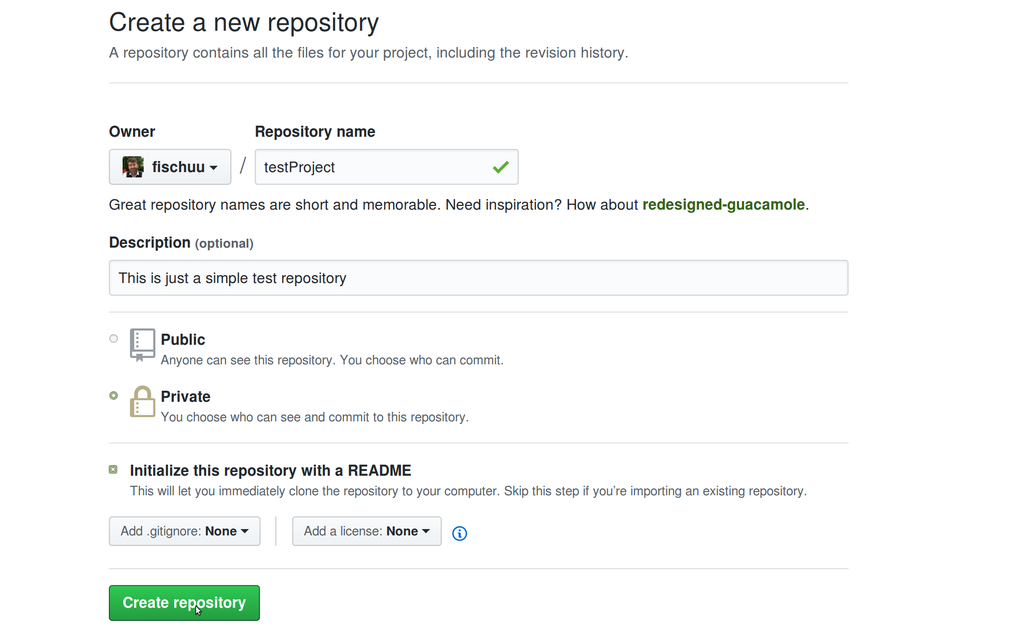

## Structure considerations

Project Setup - Structure considerations

```
.
+-- Code/
|   +-- Bash/
|   +-- Docker/
|   +-- R/
+-- Data/
+-- Notes/
+-- Results/
|   +-- Figures/
|   +-- Tables/
|   +-- Objects/
```

## File names

Project Setup - File names

## Bad examples

abstract.doc  
abstract final_new2.doc  
fig 2.jpg  
Some really nice description.txt

## Good examples

2018.10.04-Abstract_for_PAG.txt  
fig02-Scatterplot-time_vs_value.png  
Some-really-nice-description.txt

## Docker

## Background

Docker - Background

- There is often some confusion about the difference between virtual machines (Virtual Box) and containerization (docker)
- Both methods have the same aim:

*Isolate an application and its dependencies into a self-contained unit that can run anywhere*

- However, there is a large difference in the architecture between containers and VMs:

Containers *share* the host system's kernel with other containers whereas VM's rely on a hypervisor.

## Difference in architecture

Docker - Difference in architecture

[figure not shown]

## Hypervisor

Docker - Hypervisor

- A *hypervisor* is usually a piece of software that VMs run on top of
- It runs on a physical computer, referred to as the *host machine*
- The host machine provides the VMs with resources (like RAM and CPU)
- These resources are divided between VMs and can be distributed as needed.
- The hypervisor provides the VMs with a platform to manage and execute its guest OS.

## Guest OS

Docker - Guest OS

- The *guest machine* contains the application and whatever it needs to run that application.
- It also carries an entire virtualized hardware stack of its own (virtualized network adapters, storage, and CPU)
- From the inside, the guest machine behaves as its own unit with its own dedicated resources.
- From the outside, we know that VM *share* resources provided by the host machine.

## Container

Docker - Container

- A container provides operating-system-level virtualization
- Each container gets its own isolated *user-space* to allow multiple containers to run
- In principle, containers look like a VM
- BUT: Containers package up just the user-space, and not the kernel or virtual hardware like a VM does.
- Only libaries and binaries are needed, hence container are so lightweight

## Docker

Docker - Docker

- Docker is an open-source project based on Linux containers
- Containerisation is not a new concept, e.g. Google has its own container architecture
- Other popular containerisation solutions are e.g. LXC, FreeBSD jails, AIX Workload Partitions and Solaris Containers.
- However, Docker is easy, fast, community-driven and very modular
- Docker images are build of reusable layers
- The docker engine contains the docker client and daemon

## Components

Docker - Components

[figure not shown]

## Dockerfile

Docker - Dockerfile

Example of a Dockerfile (to create an Image)

```
  FROM ubuntu:16.04
  MAINTAINER Daniel Fischer <daniel.fischer@luke.fi>

  RUN apt-get update && apt-get install -y \
        curl \
        unzip \
        wget \
     && rm -rf /var/lib/apt/lists/*

  RUN wget -qO- https://github.com/alexdobin/STAR/archive/2.5.2b.tar.gz | \
      tar -xz && mv /STAR-2.5.2b/ /bin/STAR-2.5.2b/

  ENV PATH $PATH:/bin/STAR-2.5.2b/bin/Linux_x86_64_static/
```

## Docker image handling

Docker - Docker image handling

This creates a docker images and pushes it to Docker hub (account required)

```
docker build -t fischuu/star:2.5.2b .

docker push fischuu/star:2.5.2b

docker images
```

Output:

```
REPOSITORY           TAG                 IMAGE ID            CREATED             SIZE
ubuntu               16.04               14f60031763d        15 months ago       120 MB
fischuu/star         2.5.2b              31d682b42362        10 months ago       321 MB
```

## Basic Docker example

Docker - Basic Docker example

Just run a basic *Hello-World* docker example

```
fischuu@Orome ~ $ docker run hello-world
```

Output:

```
Unable to find image 'hello-world:latest' locally
latest: Pulling from library/hello-world
d1725b59e92d: Pull complete
Digest: sha256:0add3ace90ecb4adbf7777e9aacf18357296e799f81cabc9fde470971
Status: Downloaded newer image for hello-world:latest

Hello from Docker!
This message shows that your installation appears to be working correctly.
```

## List available/old docker container

Docker - List available/old docker container

```
docker ps -a
```

Output:

```
CONTAINER ID  IMAGE               COMMAND     CREATED
3813c13a6451  hello-world         "/hello"    14 minutes ago
eafbdfe3ff79  fischuu/star:2.5.2b "/bin/bash"  4 seconds ago

STATUS                      PORTS               NAMES
Exited (0) 14 minutes ago                       distracted_hugle
Up 3 seconds                                    STAR
```

## A more complex docker call

Docker - A more complex docker call

This is a more complex call to start a docker container as background daemon

```
docker run -dit -v /path/on/host/:/mp1/ \
               -v /other/path/:/mp2/ \
                --name STAR fischuu/star:2.5.2b
```

Send commands to this container

```
docker exec STAR /bin/sh -c "star createIndex myFasta.fa"
```

Stop and remove the container

```
docker stop STAR ; docker rm STAR
```

## Example cases of docker use

Docker - Example cases of docker use

Docker can be applied to a wide field of applications

- Running a RStudio session
- Start databases/webservices as daemon
- Try+Error/Debugging approaches, as containers are just disposable
- Create different testing environments on the fly
- Scale from development to production
- Fully-functional production pipelines 'without' hands-on work

## Advantages of Docker

Docker - Advantages

Containers/Images are

- small (often between 100 and 500 MB)
- stable over time (each container is a new instance)
- easily distributed (see Docker hub)
- versioned (Images are tagged)
- highly productive (e.g. in combination with pipeline scripts)
- easily scaleble (pushing to cloud computing services)

## Disadvantages of Docker

Docker - Disadvantages

Containers/Images

- are a possible security hazzard (root rights)
- require some level of discipline (especially in a hurry)
- are maybe not always available from trusted sources (e.g. for RHEL 6)

## Conclusion

## Suggested Workflow

Conclusion - Suggested workflow

- Working with plain text as much as possible:
  - script files (.R, .sh)
  - configuration (.docker)
  - documentation (.Rmd)
- Keep a documented orchestrate/master script
- Do not use workspaces, rather store objects after calculation
- Place all files in online repositories under version control
- Keep all the raw data in a read-only repository
- Run anything project realted only in corresponding (docker) container

## Supplement Material

## Further reads / Used materials

Supp. Mat. - Further reads / Used materials

Link to an overview of public data repositories:

https://www.nature.com/sdata/policies/repositories

Slides are based on the following materials:

https://medium.freecodecamp.org/a-beginner-friendly-introduction-to-containers-vms-and-docker-79a9e3e119b

https://www.learnitguide.net/2018/04/what-is-docker-get-started-from-basics.html